# Introdução à Genética Quantitativa Evolutiva

diogro@usp.br

## Genética quantitativa evolutiva

Mudança no fenótipo = Variação Genética x Seleção

## Genética quantitativa evolutiva

Mudança no fenótipo = Variação Genética x Seleção

- Variação genética -> principal responsável pela similaridade entre pais e filhos
- Se temos *muita* variação genética:
  - Evolução rápida (evolvabilidade alta);
  - Individuos aparentados são mais parecidos entre si que individuos não relacionados

## Genética quantitativa evolutiva

Mudança no fenótipo = Variação Genética x Seleção

- Variação genética -> principal responsável pela similaridade entre pais e filhos
- Se temos *pouca* variação genética:
  - evolução lenta ou ausente;
  - individuos aparentados não são mais parecidos entre si que individuos não relacionados

## Variação fenotípica é informativa da variação genética

[figure not shown]

Variação genética alta

## Variação fenotípica é informativa da variação genética

[figure not shown]

Variação genética baixa

## Partição do fenótipo do indivíduo

\[ \Huge z_i = \mu + g_i + e_i \]

- \(\huge z_i\) - fenótipo do indivíduo i
- \(\huge \mu\) - média da população
- \(\huge g_i\) - valor de genético do indivíduo i
- \(\huge e_i\) - valor ambiental do indivíduo i (tudo que não é genético)

[figure not shown]

## Valor genotípico

\[ \Huge g_i \]

- É a soma de todos os efeitos genotípicos dos loci do indivíduo i que afetam o fenótipo z

## Valor genotípico

\[ \Huge g_i \]

- É a soma de todos os efeitos genotípicos dos loci do indivíduo i que afetam o fenótipo z
- Para um loci, o valor genotípico tem dois componentes:

\[ \Huge g = a + d \]

- a é o valor de acasalamento
- d é o desvio de dominância

## Valor de acasalamento

\[ \Huge a_i \]

- É a soma de todos os efeitos médios dos alelos do indivíduo i que afetam o fenótipo z
- E o que é efeito médio de um alelo?

## Efeito médio do alelo

- Diferença na média do fenótipo dos indivíduos que tem pelo menos uma cópia do alelo (A) e a média da população:

\[ \Huge \alpha_{A} = \overline z_{A\_} - \overline z \]

## Efeito médio do alelo

- Diferença na média do fenótipo dos indivíduos que tem pelo menos uma cópia do alelo (A) e a média da população:

\[ \Huge \alpha_{A} = \overline z_{A\_} - \overline z \]

- Sacada Fisheriana:

Liga uma medida do alelo (que é herdado) com o fenótipo (que é definido pelo conjunto de genótipos, exclusivo do indivíduo).

## Uma vez na vida…

Vamos calcular o efeito médio de um alelo:

|  | genótipos | fenótipos | frequência |
| --- | --- | --- | --- |
| 1 | AA | a | p² |
| 2 | AB | d | 2pq |
| 3 | BB | -a | q² |

## Genótipos por Fenótipos

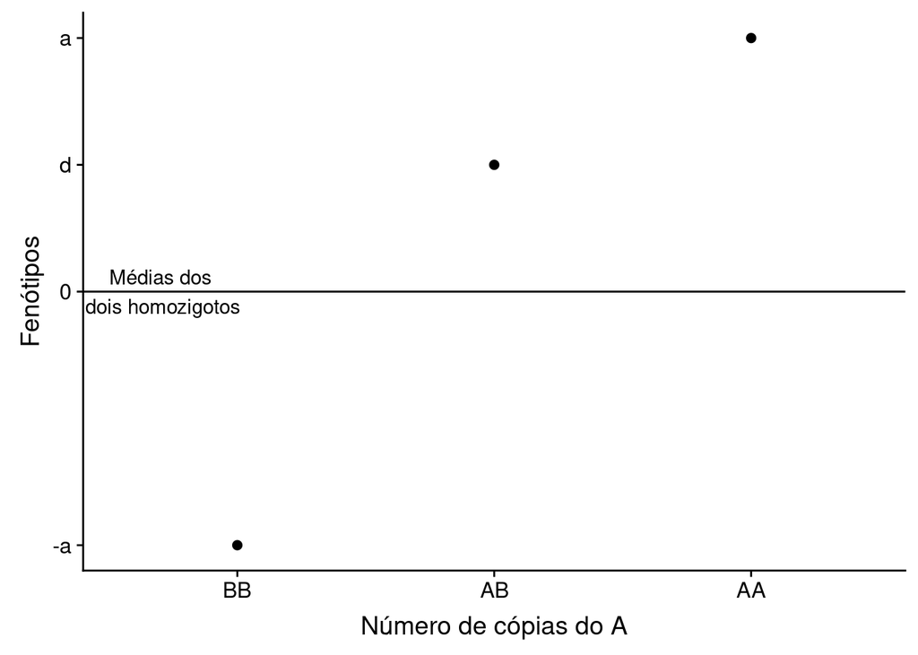

## Média da população

Lembrando que média é:

\[ \Huge \overline x = \frac{1}{N} \sum_{i = 1}^{N} x_i = \sum_{j=1}^{K} \frac{N_j}{N} x_j = \sum_{j = 1}^{K} f_{x_j} x_j \]

Podemos calcular a média somando o produdo do fenótipo pela sua frequência:

\[ \Huge \overline z = p^2 a + 2pqd + q^2 (-a) \]

Então:

\[ \Huge \overline z = (p-q)a + 2pqd \]

## E o fenótipo médio de quem tem o alelo A

- De novo, vamos multiplicar o fenótipo pela frequência, dado que o indivíduo tem o alelo A.
- O alelo A é acompanhado de um alelo A com frequência p, e é acompanhado de um alelo B com frequência q.
  - O genótipo AA tem fenótipo a,
  - O genótipo AB tem fenótipo d

Então:

\[ \Huge \overline z_A = pa + qd \]

## Efeito médio do alelo A

\[ \Huge \alpha_A = \overline z_A - \overline z = \]

\[ \Huge = (pa + qd) - [(p-q)a + 2pqd] \]

Simplificando:

\[ \Huge \alpha_A = q[a + (q - p)d] = q \alpha \]

- Depende das frequência alélicas;
- Portanto depende da população;
- Muda com tempo.

## Efeito médio de substituição

\[ \alpha = a + (q - p) d \]

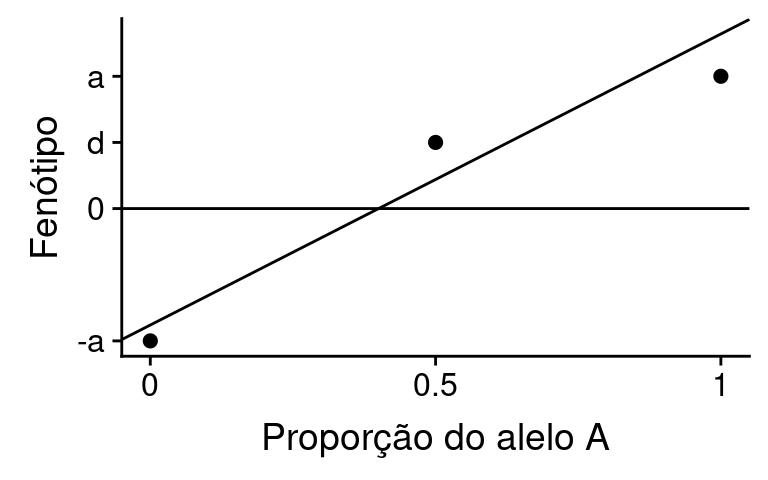

## Efeito médio de substituição

[figure not shown]

Efeito do alelo muda com sua frequência.

## Valor de acasalamento

- Diferença entre a média do valor da prole do indivíduo com parceiros tomados ao acaso da população.
- Soma do todos os efeitos médios dos alelos que afetam o fenótipo:

\[ \Huge a_i = \sum \alpha_k \]

## Recapitulando…

O fenótipo do indivíduo é definido como tendo dois componentes:

\[ \Huge z_i = \mu + g_i + e_i \]

- O componente genético, (g<sub>i</sub>, seu valor genotípico),
  - dado pelos efeitos genéticos dos alelos que o indivíduo possui
  - pode ser dividio em um componente aditivo (a, o valor de acasalamento) e de dominância (d, o desvio de dominância)
- O componente ambiental (e<sub>i</sub>, seu valor ambiental),
  - todo o resto

## Variância

A partir dessa decomposição, podemos calcular a variância do fenótipo na população:

\[ \Huge Var(z) = Var(g) + Var(e) + Cov(g, e) \]

Normalmente o genótipo e o ambiente são independentes, então:

\[ \huge Cov(g, e) = 0 \]

## Variância genética total

- A variância genética total pode ser dividida em dois componentes

\[ \Huge Var(g) = Var(a) + Var(d) \]

- A \(\huge Var(a)\) é a variância dos valores de acasalamento, chamada de variância genética aditiva
  - É a responsável pela similaridade em parentes, e portanto a parte da variância genética que importa pra evolução
- A \(\huge Var(d)\) é a variância dos desvios de dominância, chamada de variância de dominância

## Interpretação da variância aditiva

[figure not shown]

Variância dos valores na reta de regressão.

## E se as coisas não forem simples?

- Até agora, nós assumimos que os alelos só interagem dentro de locus, num processo chamado dominância.
  - Isso resulta em desvios de dominância.
- Mas, nossa vida não é fácil, e os alelos em loci diferentes também podem interagir!
  - A interação entre alelos em loci diferentes chama epistasia.

## Epistasia é muito comum

[figure not shown]

E adorável!

## Epistasia na cor de labradores

[figure not shown]

## Regressão reescrita

- O modelo aditivo de um loci pode ser escrito como:

\[ \Huge \phi = \mu + \beta_{\phi, g}g \]

- \(\huge \phi\) - fenótipo
- \(\huge \mu\) - média do fenótipo
- \(\huge \beta_{\phi, g}\) - coeficiente de regressão do fenótipo no genótipo (efeito médio de substituição)
- \(\huge g\) - frequência do alelo A no genótipo \(\huge (0, 0.5, 1)\)

## Regressão no modelo sem epistasia

- Um locus (A, alelos \(\huge A_1\), \(\huge A_2\)):

\[ \Huge \phi = \mu + \beta_{\phi, g_A}g_A \]

- Dois loci (A e B, alelos \(\huge A_1\), \(\huge A_2\) e \(\huge B_1\), \(\huge B_2\)):

\[ \Huge \phi = \mu + \beta_{\phi, g_A}g_A + \beta_{\phi, g_B}g_B \]

## Fenótipo sem epistasia

[figure not shown]

\(\huge \phi = \mu + \beta_{\phi, g_A}g_A + \beta_{\phi, g_B}g_B\)

## Fenótipo com epistasia

[figure not shown]

Superfície com epistasia

## Regressão com epistasia

- Dois loci sem interação (nem dominância):

\[ \Huge \phi = \mu + \beta_{\phi, g_A}g_A + \beta_{\phi, g_B}g_B \]

- Dois loci com (dominância e epistasia):

\[ \huge \phi = \mu + \beta_{\phi, g_A}g_A + \beta_{\phi, g_B}g_B + \beta_{\phi, g_A^2}g_A^2 + \beta_{\phi, g_B^2}g_B^2 + \beta_{\phi, g_Ag_B}g_Ag_B \]

## Fenótipo com epistasia AxA

[figure not shown]

Epistasia aditiva por aditiva

## Fenótipo com epistasia AxD

[figure not shown]

Epistasia aditiva por dominância

## Fenótipo com epistasia DxD

[figure not shown]

Epistasia dominância por dominância

## Epistasia e variância genética

- Os efeitos de interação contribuem para a variância genética, pois os efeitos médios agora dependem de outros loci.
- Epistasia pode fazer coisas bem malucas. Alguns exemplos:
  - Cheverud, JM, and EJ Routman. 1995. Genetics 139 (3): 1455–61.
  - Cheverud, JM, and EJ Routman. 1996. Evolution 50 (3): 1042.
  - Carlborg, O, et. al. 2006. Nature Genetics 38 (4): 418–20.
  - Le Rouzic, A, and J Álvarez-Castro. 2016. The American Naturalist 188 (6): E134–50.

[figure not shown]

## A teoria evolutiva completa num pacote "simples"

- O teorema de Price fornece uma fundamentação teórica para a teoria evolutiva.
- É um teorema, não uma teoria. É derivado de primeiros princípios.

## Algumas identidades preparatórias

- Covariancia entre \(\huge x\) e \(\huge y\) é igual a diferença entre a média do produto e o produto das médias:

\[ \Huge Cov(x, y) = E(xy) - \overline x \cdot \overline y \]

- O coeficiente de regressão linear de \(\huge y\) em \(\huge x\) é igual a covariância entre eles dividido pela variância de \(\huge x\)

\[ \Huge \beta_{y, x} = \frac{Cov(x, y)}{Var(x)} \]

## Esquema da demonstração

[figure not shown]

- Duas gerações, fenótipo \(\huge \phi\) nos parentais, descendentes com fenótipo \(\huge \phi_i + \delta_{i,j}\)
- \(\huge N\) indivíduos parentais, \(\huge W_i\) descendentes por parental
- Médias: \(\huge \overline \phi\), \(\huge \overline \delta_{i}\), \(\huge \overline W\)

## Média da geração dos descendentes

\[ \huge \phi' = \frac{\sum\limits_{i=1}^N \sum\limits_{j=1}^{W_i} \left ( \phi_i + \delta_{i, j} \right )}{\sum\limits_{i=1}^N W_i} \]

## Média da geração dos descendentes

\[ \huge \phi' = \frac{\sum\limits_{i=1}^N \sum\limits_{j=1}^{W_i} \left ( \phi_i + \delta_{i, j} \right )}{\sum\limits_{i=1}^N W_i} = \frac{\sum\limits_{i=1}^N \left ( \sum\limits_{j=1}^{W_i} \phi_i + \sum\limits_{j=1}^{W_i} \delta_{i, j} \right )}{\sum\limits_{i=1}^N W_i} \]

## Média da geração dos descendentes

\[ \huge \phi' = \frac{\sum\limits_{i=1}^N \sum\limits_{j=1}^{W_i} \left ( \phi_i + \delta_{i, j} \right )}{\sum\limits_{i=1}^N W_i} = \frac{\sum\limits_{i=1}^N \left ( \sum\limits_{j=1}^{W_i} \phi_i + \sum\limits_{j=1}^{W_i} \delta_{i, j} \right )}{\sum\limits_{i=1}^N W_i} \]

\[ \Huge \sum\limits_{j=1}^{W_i} \phi_i = W_i \phi_i \; \; \; \; \; \; \; \; \; \; \; \sum\limits_{j=1}^{W_i} \delta_{i, j} = W_i\overline \delta_i \]

\[ \Huge \sum\limits_{i=1}^{N} W_i = N\overline W \]

## Substituindo…

\[ \Huge \phi' = \frac{1}{N\overline W} \left [ \sum\limits_{i=1}^{N} W_i\phi_i + \sum\limits_{i=1}^{N} W_i\overline \delta_i \right ] \]

## Achando as médias

\[ \Huge \phi' = \frac{1}{N\overline W} \left [ \sum\limits_{i=1}^{N} W_i\phi_i + \sum\limits_{i=1}^{N} W_i\overline \delta_i \right ] = \] \[ \Huge \phi' = \frac{1}{\overline W} \left [ E(W\phi) + E( W\overline \delta) \right ] \]

## Aparece uma covariância…

Lembrando que: \[ \Huge Cov(x, y) = E(xy) - \overline x \cdot \overline y \]

Subsituindo \(\huge E(W\phi)\) por \(\huge Cov(W, \phi) + \overline W \cdot \overline \phi\):

\[ \Huge \phi' = \frac{1}{\overline W} \left [ E(W\phi) + E( W\overline \delta) \right ] \]

\[ \Huge \phi' = \frac{1}{\overline W} \left [ Cov(W, \phi) + \overline W \cdot \overline \phi + E( W\overline \delta) \right ] \]

## Teorema de Price

\[ \Huge \phi' = \frac{1}{\overline W} \left [ Cov(W, \phi) + \overline W \cdot \overline \phi + E( W\overline \delta) \right ] \]

\[ \Huge \boxed {\phi' - \phi = \frac{1}{\overline W} \left [ Cov(W, \phi) + E( W\overline \delta) \right ]} \]

## Teorema de Price

Mudança fenotípica tem 2 termos \[ \huge \boxed {\phi' - \phi = \frac{1}{\overline W} \left [ Cov(W, \phi) + E( W\overline \delta) \right ]} \]

- Seleção e deriva \[ \huge \frac{1}{\overline W}Cov(W, \phi) \]
- Reprodução (recombinação, regressão à média, …) \[ \huge \frac{1}{\overline W}E( W\overline \delta) \]

## Alguns aspectos do teorema

- Mudança ao longo do tempo;
- Fenótipos são totalmente genéricos;
- Relação ancestral-descendente pode ser qualquer coisa;
- Teorema estabelece a algebra entre fenótipo, aptidão, herança e evolução;
- Covariâncias, regressões e médias não tem nada a ver com estatística.

## Relação entre pais e filhos

Fenótipo médio dos descendentes de um ancestral

\[ \Huge \phi_i^o = \phi_i + \overline \delta_i \]

\[ \Huge \Delta \overline \phi = \frac{1}{\overline W} \left [ Cov(W, \phi) + E( W\overline \delta) \right ] \]

Trocando o segundo termo por uma covariância:

\[ \Huge \Delta \overline \phi = \frac{1}{\overline W} \left [ Cov(W, \phi) + Cov(W, \overline \delta) + \overline W E(\overline \delta)\right ] \]

## Juntando as covariâncias:

\[ \Huge \Delta \overline \phi = \frac{1}{\overline W} \left [ Cov(W, \phi + \overline \delta) \right ] + E(\overline \delta) \]

\[ \Huge \boxed {\Delta \overline \phi = \frac{1}{\overline W} \left [ Cov(W, \phi^o) \right ] + \overline \delta_T} \]

- \(\huge \overline \delta_T\) é a média das diferenças entre pais e filhos (não depende da aptidão)

\[ \Huge \overline \delta_T = \overline {\phi^o} - \phi \]

## Interpretando \(Cov(W, \phi^o)\)

- O termo \(\huge Cov(W, \phi^o)\) resume todos os aspectos de seleção, deriva, herança.
- Resumo: O que importa para a evolução é a covariância entre a aptidão dos pais e fenótipo dos filhos.
- Bonus: relação entre fenótipo e aptidão não precisa ser causal! Deriva vem de brinde.

## Interpretando \(\large \overline \delta_T\)

[figure not shown]

Relação não linear entre pais e filhos pode alterar a média sem seleção

## Interpretando \(\large \overline \delta_T\)

[figure not shown]

Normalmente é linear e \(\huge \overline \delta_T = 0\)

## Relação linear entre fenótipo dos pais e filhos

\[ \Huge \boxed {\Delta \overline \phi = \frac{1}{\overline W} Cov(W, \phi^o) } \]

\[ \Huge \phi^o_i = \overline \phi + \beta_{\phi^o, \phi} (\phi_i - \overline \phi) \]

Subsituindo na equação de Price (com \(\huge \overline \delta_T = 0\)):

## Relação linear entre fenótipo dos pais e filhos

\[ \Huge \boxed {\Delta \overline \phi = \frac{1}{\overline W} Cov(W, \phi^o) } \]

\[ \Huge \phi^o_i = \overline \phi + \beta_{\phi^o, \phi} (\phi_i - \overline \phi) \]

Subsituindo na equação de Price (com \(\huge \overline \delta_T = 0\)):

\[ \Huge \Delta \overline \phi = \frac{1}{\overline W} Cov(W, \beta_{\phi^o, \phi}\phi) \]

## Relação linear entre fenótipo dos pais e filhos

\[ \Huge \boxed {\Delta \overline \phi = \frac{1}{\overline W} Cov(W, \phi^o) } \]

\[ \Huge \phi^o_i = \overline \phi + \beta_{\phi^o, \phi} (\phi_i - \overline \phi) \]

Subsituindo na equação de Price (com \(\huge \overline \delta_T = 0\)):

\[ \Huge \Delta \overline \phi = \frac{1}{\overline W} \beta_{\phi^o, \phi} Cov(W, \phi) \]

## A equação do criador

\[ \Huge \Delta \overline \phi = \frac{1}{\overline W} \beta_{\phi^o, \phi} Cov(W, \phi) \]

Usando que \(\huge Cov(x, y) = \beta_{y, x}Var(x)\):

\[ \Huge \Delta \overline \phi = \frac{1}{\overline W} \frac{Cov(\phi^o, \phi)}{Var(\phi)} Cov(W, \phi) \]

## A equação do criador

\[ \Huge \boxed {\Delta \overline \phi = \frac{1}{\overline W} \frac{Cov(\phi^o, \phi)}{Var(\phi)} Cov(W, \phi)} \]

- Podemos dividir a aptidão absoluta (número de descendentes) pela média da aptidão para obter a aptidão relativa:

\[ \huge w = \frac{W}{\overline W} \]

## A equação do criador

\[ \Huge \boxed {\Delta \overline \phi = \frac{Cov(\phi^o, \phi)}{Var(\phi)} Cov(w, \phi)} \]

- \(\huge Var(\phi)\) é a variância total do fenótipo, e é usualmente representada por \(\huge V_P\).

## A equação do criador

\[ \Huge \boxed {\Delta \overline \phi = \frac{Cov(\phi^o, \phi)}{V_P} Cov(w, \phi)} \]

- A covariância entre mais e filhos (\(\huge Cov(\phi^o, \phi)\)), num modelo aditivo linear, pode ser aproximada pela variância aditiva (\(\huge V_A\)).

## A equação do criador

\[ \Huge \boxed {\Delta \overline \phi = \frac{V_A}{V_P} Cov(w, \phi)} \]

- A razão \(\huge \frac{V_A}{V_P}\) é tão importante que ela tem um nome só dela, a herdabilidade \(\huge h^2\).
- A herdabilidade mede a fração da variação total que é devido a variação nos valores de acasalamento.

## A equação do criador

\[ \Huge \boxed {\Delta \overline \phi = h^2 Cov(w, \phi)} \]

- O termo \(\huge Cov(w, \phi)\) mede o quanto a média da população muda na geração dos pais depois da seleção, e é chamado de diferencial de seleção \(\huge S\)

## A equação do criador

\[ \Huge \boxed {\Delta \overline \phi = h^2 S} \]

- Finalmente, o termo \(\huge \Delta \overline \phi\) é a mudança no fenótipo na geração dos filhos, e é chamado de resposta à seleção \(\huge R\)

## A equação do criador

\[ \Huge \boxed {R = h^2 S} \]

## A equação do criador

\[ \Huge \boxed {R = h^2 S} \]

[figure not shown]